# Epiclim Morphology analysis (Length, weight, K, HSI) - F0 adult females

Manon

2026-04-21

## Morphology analysis - Introduction

This script was used to perform morphological analyses on adult female zebrafish (15.5-16.5 months post-fertilization) following developmental exposure (2 hpf to 28 dpf) to combined climate stressors (acidification at pH 6.35, elevated temperature at 32°C) and PFOS (nominal 2 µg/L) in a 2×2×2 factorial design. Data include fish from two independent developmental exposures (exposure 2 and exposure 3). A preliminary exposure (exposure 1) was excluded due to limited sample size.

## Load required packages

```r
library(MASS)      # for rlm
library(readxl)    # open data
library(dplyr)     # code in pipe
library(ggplot2)   # for graph
library(rstatix)   # stats
library(gridExtra) # graph alignment
library(ggpubr)    # stat link with ggplot
library(multcomp)  # stat and letters
library(emmeans)   # estimated marginal means
library(sfsmisc)   # f.robftest for rlm
library(patchwork)
library(car)       # for Type 2 Anova
```

## Working environment setup

```r
# Set your working directory to the location of this Rmd file
# setwd("path/to/EpiCLim-F0-liver/morphology")
```

## Import dataset

```r
Data <- read_excel(
  normalizePath("Sampling F0-metadata_females.xlsx"),
  sheet = "All", col_names = TRUE
)
summary(Data)
```

```
##     Fish_nb        Condition           Exposure             Sex
##  Min.   :  6.00   Length:92          Length:92          Length:92
##  1st Qu.: 23.75   Class :character   Class :character   Class :character
##  Median : 55.00   Mode  :character   Mode  :character   Mode  :character
##  Mean   : 51.66
##  3rd Qu.: 79.25
##  Max.   :100.00
##
##  Condition_Sex       Length_thins       Length         Weight_g
##  Length:92          Min.   :2.200   Min.   :1.700   Min.   :0.1345
##  Class :character   1st Qu.:2.700   1st Qu.:2.175   1st Qu.:0.2124
##  Mode  :character   Median :2.900   Median :2.300   Median :0.2706
##                     Mean   :2.893   Mean   :2.285   Mean   :0.2820
##                     3rd Qu.:3.000   3rd Qu.:2.400   3rd Qu.:0.3241
##                     Max.   :3.900   Max.   :2.700   Max.   :0.6236
##
##    Weight_mg     Weight_Gonad_g    Weight_Liver_g     Weight_Brain_g
##  Min.   :134.5   Min.   :0.00020   Min.   :0.000400   Min.   :0.001500
##  1st Qu.:212.4   1st Qu.:0.01530   1st Qu.:0.002550   1st Qu.:0.003550
##  Median :270.6   Median :0.02380   Median :0.004900   Median :0.005000
##  Mean   :282.0   Mean   :0.03475   Mean   :0.005845   Mean   :0.006196
##  3rd Qu.:324.1   3rd Qu.:0.03330   3rd Qu.:0.006900   3rd Qu.:0.007350
##  Max.   :623.6   Max.   :0.47450   Max.   :0.024400   Max.   :0.024200
##                  NA's   :1         NA's   :1          NA's   :1
##   Weight_Gut_g         Name                BSI               HSI
##  Min.   :0.00440   Length:92          Min.   : 0.2706   Min.   : 0.1887
##  1st Qu.:0.01153   Class :character   1st Qu.: 1.4215   1st Qu.: 1.0775
##  Median :0.01770   Mode  :character   Median : 1.9717   Median : 1.6313
##  Mean   :0.02015                      Mean   : 2.4216   Mean   : 2.1876
##  3rd Qu.:0.02710                      3rd Qu.: 2.4705   3rd Qu.: 2.5040
##  Max.   :0.05510                      Max.   :13.9562   Max.   :11.8161
##                                       NA's   :1         NA's   :1
##       GSI                  K         Sampling_Date      Fish_age_months
##  Min.   :  0.09434   Min.   :1.158   Min.   : 3042025   Min.   :15.50
##  1st Qu.:  6.78824   1st Qu.:1.917   1st Qu.: 3042025   1st Qu.:15.50
##  Median : 10.34854   Median :2.289   Median : 3042025   Median :16.50
##  Mean   : 11.45304   Mean   :2.360   Mean   :15194199   Mean   :16.03
##  3rd Qu.: 12.76290   3rd Qu.:2.707   3rd Qu.:29042025   3rd Qu.:16.50
##  Max.   :154.91348   Max.   :4.557   Max.   :29042025   Max.   :16.50
##  NA's   :1
```

## Data treatment

Remove “_” in some column values.

```r
Data$Exposure <- gsub("_", "", Data$Exposure)

# Sample sizes summary
Data %>%
  group_by(Condition) %>%
  summarise(n = n(), .groups = "drop") %>%
  print()
```

```
## # A tibble: 8 × 2
##   Condition        n
##   <chr>        <int>
## 1 Acid            12
## 2 AcidPFOS        12
## 3 AcidPFOSTemp    11
## 4 AcidTemp        11
## 5 Control         12
## 6 PFOS            10
## 7 PFOSTemp        13
## 8 Temp            11
```

```r
Data$Fish_nb <- as.factor(Data$Fish_nb)
Data$Condition <- as.factor(Data$Condition)
Data$Exposure <- as.factor(Data$Exposure)
summary(Data)
```

```
##     Fish_nb          Condition  Exposure     Sex            Condition_Sex
##  7      : 2   PFOSTemp    :13   2:49     Length:92          Length:92
##  8      : 2   Acid        :12   3:43     Class :character   Class :character
##  9      : 2   AcidPFOS    :12            Mode  :character   Mode  :character
##  10     : 2   Control     :12
##  11     : 2   AcidPFOSTemp:11
##  19     : 2   AcidTemp    :11
##  (Other):80   (Other)     :21
##   Length_thins       Length         Weight_g        Weight_mg
##  Min.   :2.200   Min.   :1.700   Min.   :0.1345   Min.   :134.5
##  1st Qu.:2.700   1st Qu.:2.175   1st Qu.:0.2124   1st Qu.:212.4
##  Median :2.900   Median :2.300   Median :0.2706   Median :270.6
##  Mean   :2.893   Mean   :2.285   Mean   :0.2820   Mean   :282.0
##  3rd Qu.:3.000   3rd Qu.:2.400   3rd Qu.:0.3241   3rd Qu.:324.1
##  Max.   :3.900   Max.   :2.700   Max.   :0.6236   Max.   :623.6
##
##  Weight_Gonad_g    Weight_Liver_g     Weight_Brain_g      Weight_Gut_g
##  Min.   :0.00020   Min.   :0.000400   Min.   :0.001500   Min.   :0.00440
##  1st Qu.:0.01530   1st Qu.:0.002550   1st Qu.:0.003550   1st Qu.:0.01153
##  Median :0.02380   Median :0.004900   Median :0.005000   Median :0.01770
##  Mean   :0.03475   Mean   :0.005845   Mean   :0.006196   Mean   :0.02015
##  3rd Qu.:0.03330   3rd Qu.:0.006900   3rd Qu.:0.007350   3rd Qu.:0.02710
##  Max.   :0.47450   Max.   :0.024400   Max.   :0.024200   Max.   :0.05510
##  NA's   :1         NA's   :1          NA's   :1
##      Name                BSI               HSI               GSI
##  Length:92          Min.   : 0.2706   Min.   : 0.1887   Min.   :  0.09434
##  Class :character   1st Qu.: 1.4215   1st Qu.: 1.0775   1st Qu.:  6.78824
##  Mode  :character   Median : 1.9717   Median : 1.6313   Median : 10.34854
##                     Mean   : 2.4216   Mean   : 2.1876   Mean   : 11.45304
##                     3rd Qu.: 2.4705   3rd Qu.: 2.5040   3rd Qu.: 12.76290
##                     Max.   :13.9562   Max.   :11.8161   Max.   :154.91348
##                     NA's   :1         NA's   :1         NA's   :1
##        K         Sampling_Date      Fish_age_months
##  Min.   :1.158   Min.   : 3042025   Min.   :15.50
##  1st Qu.:1.917   1st Qu.: 3042025   1st Qu.:15.50
##  Median :2.289   Median : 3042025   Median :16.50
##  Mean   :2.360   Mean   :15194199   Mean   :16.03
##  3rd Qu.:2.707   3rd Qu.:29042025   3rd Qu.:16.50
##  Max.   :4.557   Max.   :29042025   Max.   :16.50
##
```

```r
#Check missing values
morph_vars <- c("Length_thins", "Length", "Weight_g", "BSI", "HSI", "GSI", "K")
print(colSums(is.na(Data[, morph_vars])))
```

```
## Length_thins       Length     Weight_g          BSI          HSI          GSI
##            0            0            0            1            1            1
##            K
##            0
```

```r
#Color code for conditions (used across all plots)
myColors <- c(
  "Control" = "#4C78A8", "Acid" = "#59A14F", "Temp" = "#E45756",
  "PFOS" = "#B279A2", "AcidTemp" = "#8C6D1F", "PFOSTemp" = "#AD1457",
  "AcidPFOS" = "#5B6D5B", "AcidPFOSTemp" = "#7B3F5A")
```

## PCA

```r
#Set reference levels (Control as reference for Condition, Expo 2 as reference)
Data$Condition <- factor(Data$Condition,
  levels = c("Control", "Acid", "Temp", "PFOS",
             "AcidTemp", "AcidPFOS", "PFOSTemp", "AcidPFOSTemp"))
Data$Exposure <- relevel(factor(Data$Exposure), ref = "2")

#Check sample sizes per condition
table(Data$Condition, Data$Exposure)
```

```
##
##                2 3
##   Control      6 6
##   Acid         6 6
##   Temp         6 5
##   PFOS         6 4
##   AcidTemp     6 5
##   AcidPFOS     6 6
##   PFOSTemp     7 6
##   AcidPFOSTemp 6 5
```

```r
#PCA on complete lines (no missing values) using raw measurements only
#(indices like K, BSI are derived from these, including them would double-count variance)
morph_metrics <- c("Length", "Weight_mg", "Weight_Liver_g")
Data_pca <- Data[complete.cases(Data[, morph_metrics]), ]
cat("Fish used:", nrow(Data_pca), "out of", nrow(Data), "\n")
```

```
## Fish used: 91 out of 92
```

```r
pca <- prcomp(Data_pca[, morph_metrics], scale. = TRUE)
var_exp <- round(summary(pca)$importance[2, 1:2] * 100, 1)
summary(pca)
```

```
## Importance of components:
##                           PC1    PC2    PC3
## Standard deviation     1.3044 0.9303 0.6581
## Proportion of Variance 0.5671 0.2885 0.1444
## Cumulative Proportion  0.5671 0.8556 1.0000
```

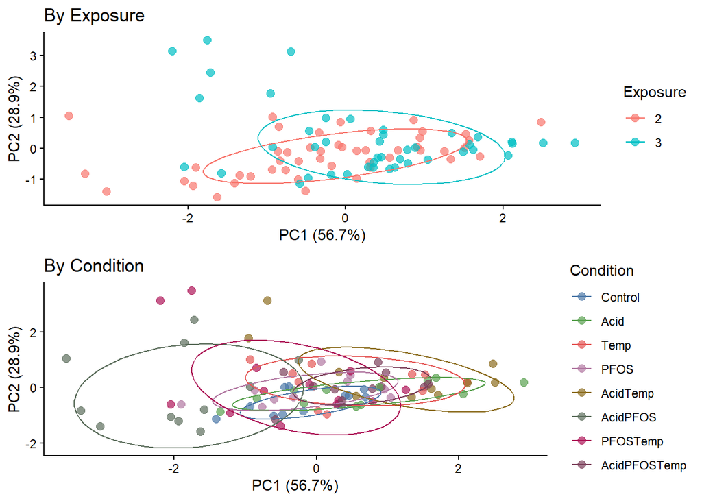

```r
pca_df <- data.frame(
  PC1 = pca$x[, 1], PC2 = pca$x[, 2],
  Condition = Data_pca$Condition,
  Exposure = Data_pca$Exposure)

# By Exposure
p1 <- ggplot(pca_df, aes(PC1, PC2, color = Exposure)) +
  geom_point(size = 2.5, alpha = 0.7) +
  stat_ellipse(level = 0.68) +
  labs(x = paste0("PC1 (", var_exp[1], "%)"),
       y = paste0("PC2 (", var_exp[2], "%)"),
       title = "By Exposure") +
  theme_classic()

# By Condition
p2 <- ggplot(pca_df, aes(PC1, PC2, color = Condition)) +
  geom_point(size = 2.5, alpha = 0.7) +
  stat_ellipse(level = 0.68) +
  scale_color_manual(values = myColors) +
  labs(x = paste0("PC1 (", var_exp[1], "%)"),
       y = paste0("PC2 (", var_exp[2], "%)"),
       title = "By Condition") +
  theme_classic()

grid.arrange(p1, p2)
```

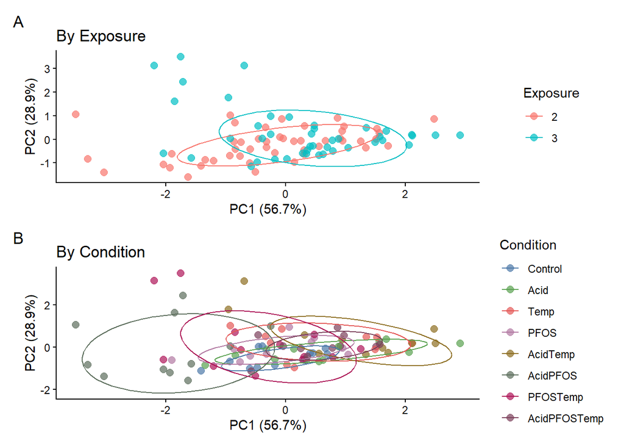

```r
combined_PCA <- (p1/p2) +
  plot_annotation(tag_levels = "A")

combined_PCA
```

```r
ggsave("PCA_females.png", plot = combined_PCA,
       width = 7, height = 5, units = "in", dpi = 600)
```

PCA shows no strict batch effect. Expo 2 and 3 overlap.

## Log2 transform data

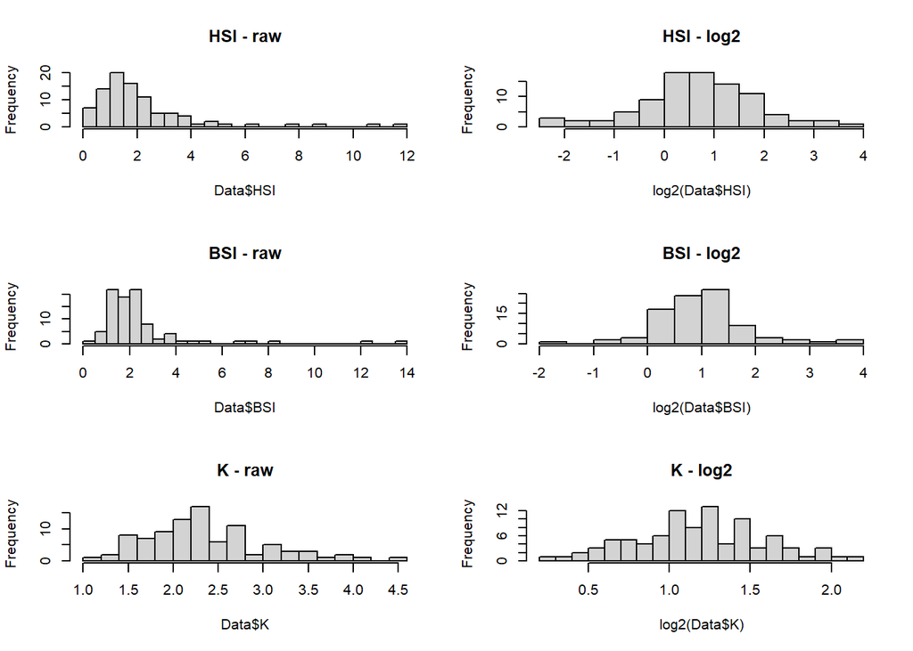

```r
Data$log2_Length_thins <- log2(Data$Length_thins)
Data$log2_Length <- log2(Data$Length)
Data$log2_Weight <- log2(Data$Weight_g)
Data$log2_Weight_mg <- log2(Data$Weight_mg)
Data$log2_BSI <- log2(Data$BSI)
Data$log2_HSI <- log2(Data$HSI)
Data$log2_GSI <- log2(Data$GSI)
Data$log2_K <- log2(Data$K)

#Check the distribution
par(mfrow = c(3, 2))
hist(Data$HSI, main = "HSI - raw", breaks = 20)
hist(log2(Data$HSI), main = "HSI - log2", breaks = 20)
hist(Data$BSI, main = "BSI - raw", breaks = 20)
hist(log2(Data$BSI), main = "BSI - log2", breaks = 20)
hist(Data$K, main = "K - raw", breaks = 20)
hist(log2(Data$K), main = "K - log2", breaks = 20)
```

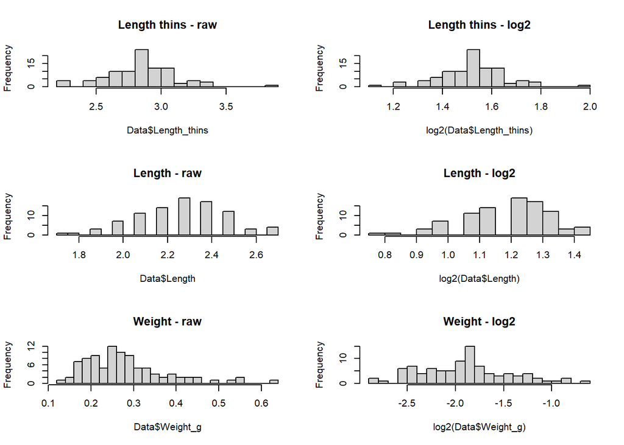

```r
par(mfrow = c(3, 2))
hist(Data$Length_thins, main = "Length thins - raw", breaks = 20)
hist(log2(Data$Length_thins), main = "Length thins - log2", breaks = 20)
hist(Data$Length, main = "Length - raw", breaks = 20)
hist(log2(Data$Length), main = "Length - log2", breaks = 20)
hist(Data$Weight_g, main = "Weight - raw", breaks = 20)
hist(log2(Data$Weight_g), main = "Weight - log2", breaks = 20)
```

## Length analysis

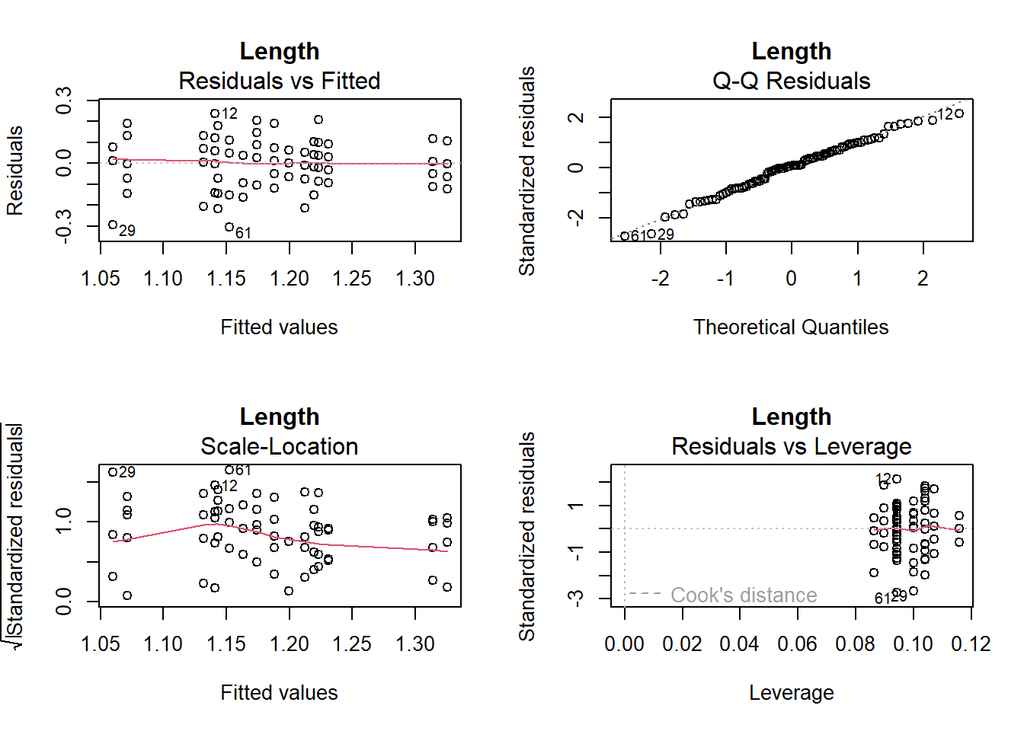

```r
#Diagnostic on standard lm first
model_length <- lm(log2_Length ~ Condition + Exposure, data = Data)
par(mfrow = c(2, 2))
plot(model_length, main = "Length")
```

```r
#residuals vs fitted = random scatter around zero --> good
#QQ plot: some fish differ strongly from the line --> outliers --> switch to rlm

#Robust regression
model_length_robust <- rlm(log2_Length ~ Condition + Exposure, data = Data)

#Omnibus F-test on Condition
f.robftest(model_length_robust, var = c("ConditionAcid", "ConditionTemp", "ConditionPFOS",
                                        "ConditionAcidTemp", "ConditionAcidPFOS",
                                        "ConditionPFOSTemp", "ConditionAcidPFOSTemp"))
```

```
##
##  robust F-test (as if non-random weights)
##
## data:  from rlm(formula = log2_Length ~ Condition + Exposure, data = Data)
## F = 4.1983, p-value = 0.0005268
## alternative hypothesis: two.sided
## null values:
##         ConditionAcid         ConditionTemp         ConditionPFOS
##                     0                     0                     0
##     ConditionAcidTemp     ConditionAcidPFOS     ConditionPFOSTemp
##                     0                     0                     0
## ConditionAcidPFOSTemp
##                     0
```

```r
f.robftest(model_length_robust, var = "Exposure3")
```

```
##
##  robust F-test (as if non-random weights)
##
## data:  from rlm(formula = log2_Length ~ Condition + Exposure, data = Data)
## F = 0.14957, p-value = 0.6999
## alternative hypothesis: true Exposure3 is not equal to 0
```

```r
#Condition effect present. Exposure doesn't matter --> we can keep our 2 batches as technical replicates

#Dunnett: each treatment vs Control
emm <- emmeans(model_length_robust, ~ Condition)
contrast(emm, method = "trt.vs.ctrl", ref = "Control")
```

```
##  contrast               estimate     SE df z.ratio p.value
##  Acid - Control         -0.07228 0.0486 NA  -1.488  0.5048
##  Temp - Control         -0.07885 0.0497 NA  -1.587  0.4416
##  PFOS - Control         -0.03514 0.0510 NA  -0.689  0.9322
##  AcidTemp - Control     -0.14888 0.0497 NA  -2.996  0.0170
##  AcidPFOS - Control      0.09439 0.0486 NA   1.943  0.2447
##  PFOSTemp - Control     -0.00759 0.0476 NA  -0.159  0.9993
##  AcidPFOSTemp - Control -0.06141 0.0497 NA  -1.236  0.6681
##
## Results are averaged over the levels of: Exposure
## P value adjustment: dunnettx method for 7 tests
```

```r
#All pairwise comparisons (BH-adjusted, 28 tests)
pairs(emm, adjust = "BH")
```

```
##  contrast                estimate     SE df z.ratio p.value
##  Control - Acid           0.07228 0.0486 NA   1.488  0.2685
##  Control - Temp           0.07885 0.0497 NA   1.587  0.2626
##  Control - PFOS           0.03514 0.0510 NA   0.689  0.6249
##  Control - AcidTemp       0.14888 0.0497 NA   2.996  0.0153
##  Control - AcidPFOS      -0.09439 0.0486 NA  -1.943  0.1457
##  Control - PFOSTemp       0.00759 0.0476 NA   0.159  0.8949
##  Control - AcidPFOSTemp   0.06141 0.0497 NA   1.236  0.3368
##  Acid - Temp              0.00656 0.0497 NA   0.132  0.8949
##  Acid - PFOS             -0.03714 0.0510 NA  -0.728  0.6221
##  Acid - AcidTemp          0.07659 0.0497 NA   1.542  0.2653
##  Acid - AcidPFOS         -0.16667 0.0486 NA  -3.431  0.0056
##  Acid - PFOSTemp         -0.06469 0.0476 NA  -1.358  0.2875
##  Acid - AcidPFOSTemp     -0.01088 0.0497 NA  -0.219  0.8903
##  Temp - PFOS             -0.04371 0.0520 NA  -0.840  0.5610
##  Temp - AcidTemp          0.07003 0.0507 NA   1.380  0.2875
##  Temp - AcidPFOS         -0.17323 0.0497 NA  -3.487  0.0056
##  Temp - PFOSTemp         -0.07126 0.0488 NA  -1.462  0.2685
##  Temp - AcidPFOSTemp     -0.01744 0.0507 NA  -0.344  0.8188
##  PFOS - AcidTemp          0.11374 0.0520 NA   2.187  0.1006
##  PFOS - AcidPFOS         -0.12953 0.0510 NA  -2.539  0.0445
##  PFOS - PFOSTemp         -0.02755 0.0501 NA  -0.550  0.7088
##  PFOS - AcidPFOSTemp      0.02627 0.0520 NA   0.505  0.7158
##  AcidTemp - AcidPFOS     -0.24326 0.0497 NA  -4.896 <0.0001
##  AcidTemp - PFOSTemp     -0.14129 0.0488 NA  -2.898  0.0175
##  AcidTemp - AcidPFOSTemp -0.08747 0.0507 NA  -1.724  0.2157
##  AcidPFOS - PFOSTemp      0.10198 0.0476 NA   2.140  0.1006
##  AcidPFOS - AcidPFOSTemp  0.15579 0.0497 NA   3.136  0.0120
##  PFOSTemp - AcidPFOSTemp  0.05382 0.0488 NA   1.104  0.3973
##
## Results are averaged over the levels of: Exposure
## P value adjustment: BH method for 28 tests
```

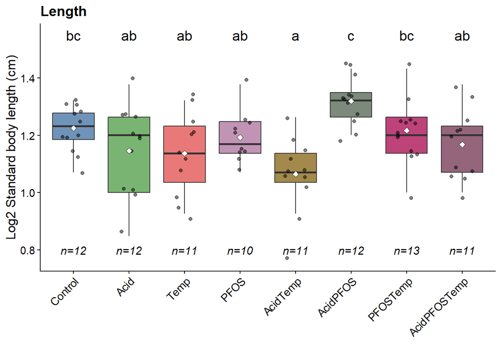

```r
#Compact letter display for the plot
cld_df <- as.data.frame(cld(emm, Letters = letters, adjust = "BH"))
cld_df$.group <- trimws(cld_df$.group)

#Sample sizes
n_df <- Data %>%
  filter(!is.na(log2_Length)) %>%
  group_by(Condition) %>%
  summarise(n = n(), .groups = "drop") %>%
  mutate(label = paste0("n=", n))

#Plot
length_plot_females <- ggplot(Data, aes(x = Condition, y = log2_Length, fill = Condition)) +
  geom_boxplot(alpha = 0.8, outlier.shape = NA) +
  geom_jitter(width = 0.2, size = 1.5, alpha = 0.5) +
  stat_summary(fun = mean, geom = "point", shape = 23, size = 2, fill = "white") +
  scale_fill_manual(values = myColors) +
  geom_text(data = cld_df, aes(x = Condition, y = 1.55, label = .group),
            size = 5, inherit.aes = FALSE) +
  geom_text(data = n_df, aes(x = Condition, y = 0.8, label = label),
            size = 4, fontface = "italic", inherit.aes = FALSE) +
  labs(y = "Log2 Standard body length (cm)", x = "", title = "Length") +
  theme_classic() +
  theme(legend.position = "none",
        axis.text.x = element_text(angle = 45, hjust = 1, size = 11),
        axis.text.y = element_text(size = 11),
        axis.title.y = element_text(size = 13),
        plot.title = element_text(size = 14, face = "bold"))
length_plot_females
```

```r
ggsave("length_plot.png", plot = length_plot_females,
       width = 7, height = 5, units = "in", dpi = 600)
```

## Weight analysis

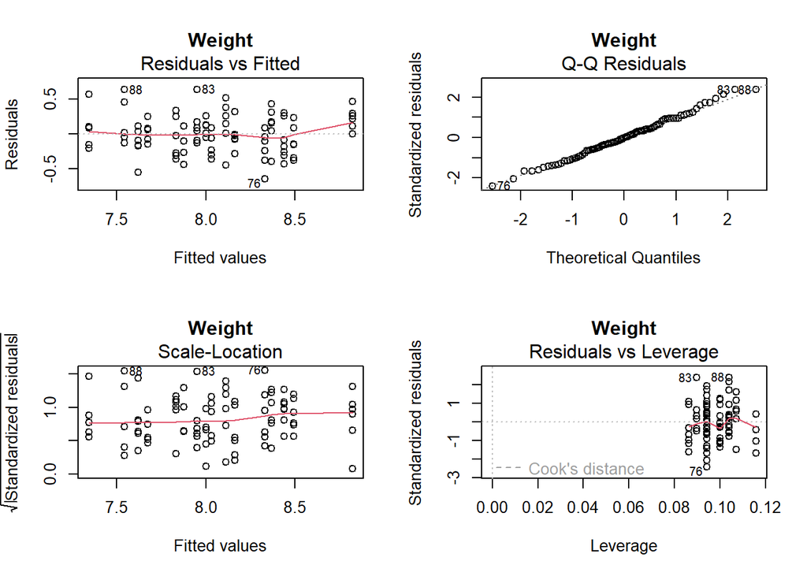

```r
#Diagnostic on standard lm
model_Weight <- lm(log2_Weight_mg ~ Condition + Exposure, data = Data)
par(mfrow = c(2, 2))
plot(model_Weight, main = "Weight")
```

```r
#residuals vs fitted = random scatter around zero --> good
#QQ plot ok --> keep lm

anova(model_Weight)
```

```
## Analysis of Variance Table
##
## Response: log2_Weight_mg
##           Df Sum Sq Mean Sq F value    Pr(>F)
## Condition  7 7.6179  1.0883  13.863 9.190e-12 ***
## Exposure   1 5.5036  5.5036  70.105 1.174e-12 ***
## Residuals 83 6.5159  0.0785
## ---
## Signif. codes:  0 '***' 0.001 '**' 0.01 '*' 0.05 '.' 0.1 ' ' 1
```

```r
#Exposure effect probably due to age (expo 2 fish are older --> bigger)
#Condition effect also present

#Dunnett: each treatment vs Control
emm <- emmeans(model_Weight, ~ Condition)
contrast(emm, method = "trt.vs.ctrl", ref = "Control")
```

```
##  contrast               estimate    SE df t.ratio p.value
##  Acid - Control          -0.3823 0.114 83  -3.342  0.0079
##  Temp - Control          -0.3304 0.117 83  -2.824  0.0348
##  PFOS - Control          -0.1260 0.120 83  -1.049  0.7797
##  AcidTemp - Control      -0.6606 0.117 83  -5.647 <0.0001
##  AcidPFOS - Control       0.3307 0.114 83   2.891  0.0291
##  PFOSTemp - Control      -0.0526 0.112 83  -0.469  0.9788
##  AcidPFOSTemp - Control  -0.4609 0.117 83  -3.939  0.0011
##
## Results are averaged over the levels of: Exposure
## P value adjustment: dunnettx method for 7 tests
```

```r
#All pairwise comparisons
pairs(emm, adjust = "BH")
```

```
##  contrast                estimate    SE df t.ratio p.value
##  Control - Acid            0.3823 0.114 83   3.342  0.0029
##  Control - Temp            0.3304 0.117 83   2.824  0.0111
##  Control - PFOS            0.1260 0.120 83   1.049  0.3469
##  Control - AcidTemp        0.6606 0.117 83   5.647 <0.0001
##  Control - AcidPFOS       -0.3307 0.114 83  -2.891  0.0098
##  Control - PFOSTemp        0.0526 0.112 83   0.469  0.6585
##  Control - AcidPFOSTemp    0.4609 0.117 83   3.939  0.0006
##  Acid - Temp              -0.0519 0.117 83  -0.444  0.6585
##  Acid - PFOS              -0.2563 0.120 83  -2.134  0.0501
##  Acid - AcidTemp           0.2783 0.117 83   2.379  0.0289
##  Acid - AcidPFOS          -0.7130 0.114 83  -6.233 <0.0001
##  Acid - PFOSTemp          -0.3297 0.112 83  -2.938  0.0092
##  Acid - AcidPFOSTemp       0.0786 0.117 83   0.672  0.5641
##  Temp - PFOS              -0.2044 0.122 83  -1.669  0.1258
##  Temp - AcidTemp           0.3302 0.119 83   2.764  0.0123
##  Temp - AcidPFOS          -0.6611 0.117 83  -5.651 <0.0001
##  Temp - PFOSTemp          -0.2778 0.115 83  -2.420  0.0276
##  Temp - AcidPFOSTemp       0.1305 0.119 83   1.092  0.3384
##  PFOS - AcidTemp           0.5347 0.122 83   4.366  0.0001
##  PFOS - AcidPFOS          -0.4567 0.120 83  -3.802  0.0008
##  PFOS - PFOSTemp          -0.0733 0.118 83  -0.622  0.5769
##  PFOS - AcidPFOSTemp       0.3349 0.122 83   2.735  0.0126
##  AcidTemp - AcidPFOS      -0.9914 0.117 83  -8.474 <0.0001
##  AcidTemp - PFOSTemp      -0.6080 0.115 83  -5.297 <0.0001
##  AcidTemp - AcidPFOSTemp  -0.1998 0.119 83  -1.672  0.1258
##  AcidPFOS - PFOSTemp       0.3834 0.112 83   3.417  0.0025
##  AcidPFOS - AcidPFOSTemp   0.7916 0.117 83   6.767 <0.0001
##  PFOSTemp - AcidPFOSTemp   0.4082 0.115 83   3.557  0.0017
##
## Results are averaged over the levels of: Exposure
## P value adjustment: BH method for 28 tests
```

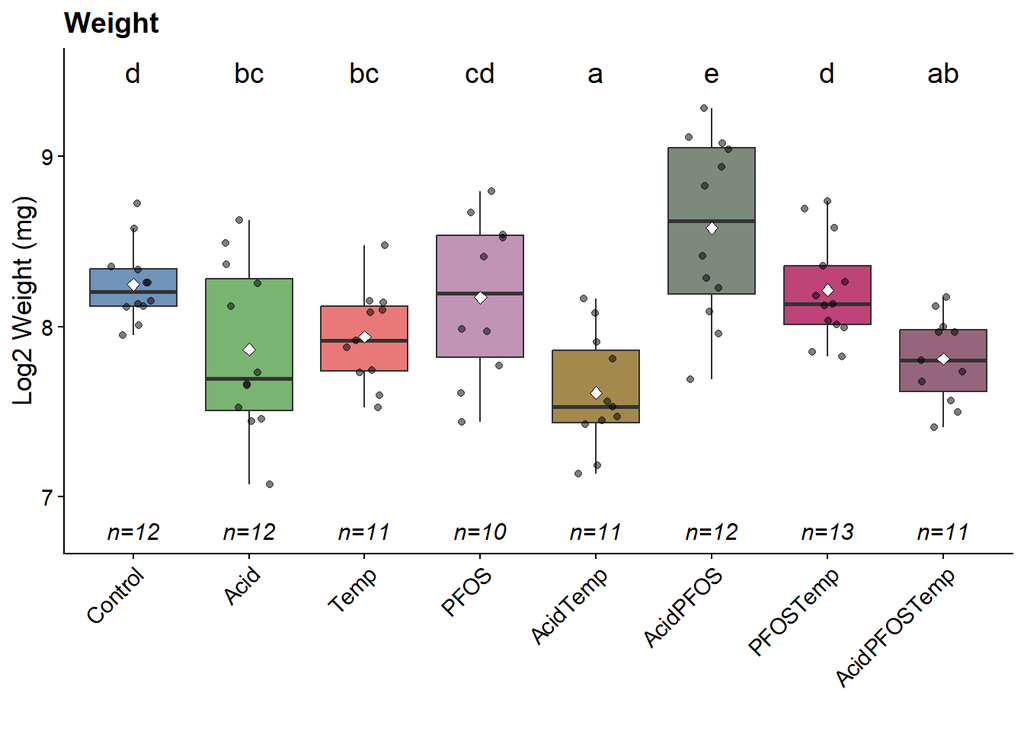

```r
#Compact letter display
cld_df <- as.data.frame(cld(emm, Letters = letters, adjust = "BH"))
cld_df$.group <- trimws(cld_df$.group)

#Sample sizes
n_df <- Data %>%
  filter(!is.na(log2_Weight_mg)) %>%
  group_by(Condition) %>%
  summarise(n = n(), .groups = "drop") %>%
  mutate(label = paste0("n=", n))

#Plot
weight_plot_females <- ggplot(Data, aes(x = Condition, y = log2_Weight_mg, fill = Condition)) +
  geom_boxplot(alpha = 0.8, outlier.shape = NA) +
  geom_jitter(width = 0.2, size = 1.5, alpha = 0.5) +
  stat_summary(fun = mean, geom = "point", shape = 23, size = 2, fill = "white") +
  scale_fill_manual(values = myColors) +
  geom_text(data = cld_df, aes(x = Condition, y = 9.5, label = .group),
            size = 5, inherit.aes = FALSE) +
  geom_text(data = n_df, aes(x = Condition, y = 6.8, label = label),
            size = 4, fontface = "italic", inherit.aes = FALSE) +
  labs(y = "Log2 Weight (mg)", x = "", title = "Weight") +
  theme_classic() +
  theme(legend.position = "none",
        axis.text.x = element_text(angle = 45, hjust = 1, size = 11),
        axis.text.y = element_text(size = 11),
        axis.title.y = element_text(size = 13),
        plot.title = element_text(size = 14, face = "bold"))
weight_plot_females
```

```r
ggsave("weight_plot.png", plot = weight_plot_females,
       width = 7, height = 5, units = "in", dpi = 600)
```

## HSI analysis

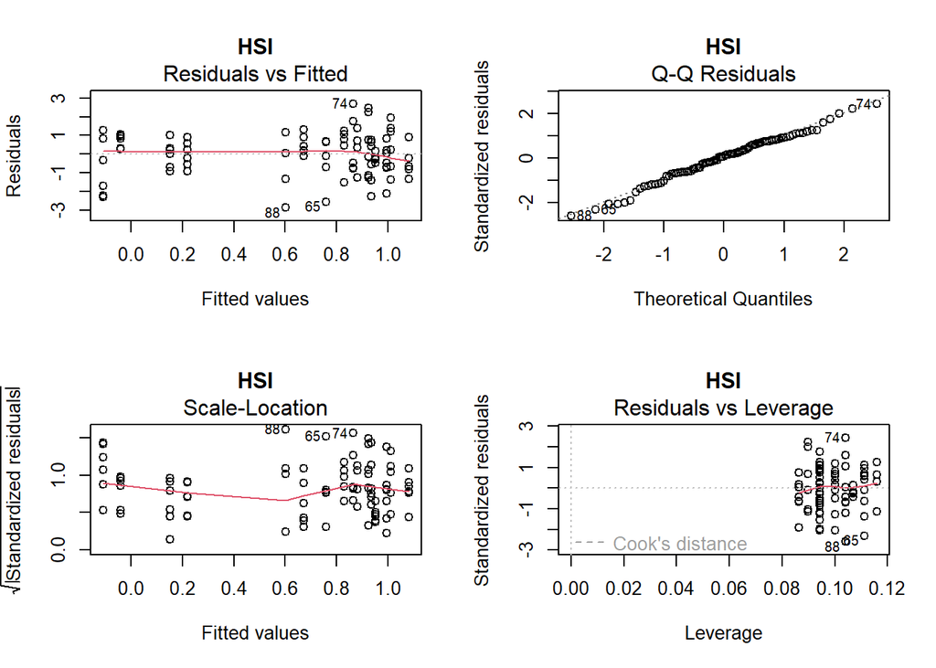

```r
#Diagnostic on standard lm
model_HSI <- lm(log2_HSI ~ Condition + Exposure, data = Data)
par(mfrow = c(2, 2))
plot(model_HSI, main = "HSI")
```

```r
#residuals vs fitted = random scatter around zero --> good
#QQ plot some outliers --> rlm

cooksd <- cooks.distance(model_HSI)
threshold <- 4 / (nrow(Data) - length(coef(model_HSI)))
outliers <- which(cooksd > threshold)
outliers
```

```
## 25 56 65 74 86 88
## 24 55 64 73 85 87
```

```r
#Robust regression
model_HSI_robust <- rlm(log2_HSI ~ Condition + Exposure, data = Data)

#Omnibus F-test
f.robftest(model_HSI_robust, var = c("ConditionAcid", "ConditionTemp", "ConditionPFOS",
                                     "ConditionAcidTemp", "ConditionAcidPFOS",
                                     "ConditionPFOSTemp", "ConditionAcidPFOSTemp"))
```

```
##
##  robust F-test (as if non-random weights)
##
## data:  from rlm(formula = log2_HSI ~ Condition + Exposure, data = Data)
## F = 1.0251, p-value = 0.4201
## alternative hypothesis: two.sided
## null values:
##         ConditionAcid         ConditionTemp         ConditionPFOS
##                     0                     0                     0
##     ConditionAcidTemp     ConditionAcidPFOS     ConditionPFOSTemp
##                     0                     0                     0
## ConditionAcidPFOSTemp
##                     0
```

```r
f.robftest(model_HSI_robust, var = "Exposure3")
```

```
##
##  robust F-test (as if non-random weights)
##
## data:  from rlm(formula = log2_HSI ~ Condition + Exposure, data = Data)
## F = 0.18576, p-value = 0.6676
## alternative hypothesis: true Exposure3 is not equal to 0
```

```r
#No effects whatsoever.

#Sensitivity check: ANOVA without extreme outliers (exploratory)
Data_no_out <- Data[!(rownames(Data) %in% outliers), ]
model_HSI_aov <- aov(log2_HSI ~ Condition + Exposure, data = Data_no_out)
summary(model_HSI_aov)
```

```
##             Df Sum Sq Mean Sq F value Pr(>F)
## Condition    7  14.32  2.0458   1.432  0.205
## Exposure     1   0.01  0.0083   0.006  0.939
## Residuals   76 108.58  1.4287
## 1 observation deleted due to missingness
```

```r
#still no effects

#Dunnett: each treatment vs Control
emm <- emmeans(model_HSI_robust, ~ Condition)
contrast(emm, method = "trt.vs.ctrl", ref = "Control")
```

```
##  contrast               estimate    SE df z.ratio p.value
##  Acid - Control         -0.00229 0.456 NA  -0.005  1.0000
##  Temp - Control          0.79717 0.478 NA   1.666  0.3927
##  PFOS - Control          0.71287 0.479 NA   1.488  0.5044
##  AcidTemp - Control      0.60259 0.466 NA   1.292  0.6325
##  AcidPFOS - Control      0.78120 0.456 NA   1.713  0.3654
##  PFOSTemp - Control      0.64089 0.447 NA   1.433  0.5407
##  AcidPFOSTemp - Control  0.62718 0.466 NA   1.344  0.5983
##
## Results are averaged over the levels of: Exposure
## P value adjustment: dunnettx method for 7 tests
```

```r
#All pairwise comparisons (BH-adjusted)
pairs(emm, adjust = "BH")
```

```
##  contrast                estimate    SE df z.ratio p.value
##  Control - Acid           0.00229 0.456 NA   0.005  0.9960
##  Control - Temp          -0.79717 0.478 NA  -1.666  0.4583
##  Control - PFOS          -0.71287 0.479 NA  -1.488  0.4583
##  Control - AcidTemp      -0.60259 0.466 NA  -1.292  0.4583
##  Control - AcidPFOS      -0.78120 0.456 NA  -1.713  0.4583
##  Control - PFOSTemp      -0.64089 0.447 NA  -1.433  0.4583
##  Control - AcidPFOSTemp  -0.62718 0.466 NA  -1.344  0.4583
##  Acid - Temp             -0.79946 0.478 NA  -1.671  0.4583
##  Acid - PFOS             -0.71517 0.479 NA  -1.493  0.4583
##  Acid - AcidTemp         -0.60488 0.466 NA  -1.297  0.4583
##  Acid - AcidPFOS         -0.78350 0.456 NA  -1.718  0.4583
##  Acid - PFOSTemp         -0.64319 0.447 NA  -1.438  0.4583
##  Acid - AcidPFOSTemp     -0.62947 0.466 NA  -1.349  0.4583
##  Temp - PFOS              0.08430 0.500 NA   0.169  0.9960
##  Temp - AcidTemp          0.19458 0.488 NA   0.399  0.9960
##  Temp - AcidPFOS          0.01597 0.478 NA   0.033  0.9960
##  Temp - PFOSTemp          0.15627 0.470 NA   0.332  0.9960
##  Temp - AcidPFOSTemp      0.16999 0.488 NA   0.348  0.9960
##  PFOS - AcidTemp          0.11029 0.488 NA   0.226  0.9960
##  PFOS - AcidPFOS         -0.06833 0.479 NA  -0.143  0.9960
##  PFOS - PFOSTemp          0.07198 0.470 NA   0.153  0.9960
##  PFOS - AcidPFOSTemp      0.08569 0.488 NA   0.175  0.9960
##  AcidTemp - AcidPFOS     -0.17861 0.466 NA  -0.383  0.9960
##  AcidTemp - PFOSTemp     -0.03831 0.458 NA  -0.084  0.9960
##  AcidTemp - AcidPFOSTemp -0.02459 0.476 NA  -0.052  0.9960
##  AcidPFOS - PFOSTemp      0.14031 0.447 NA   0.314  0.9960
##  AcidPFOS - AcidPFOSTemp  0.15402 0.466 NA   0.330  0.9960
##  PFOSTemp - AcidPFOSTemp  0.01372 0.458 NA   0.030  0.9960
##
## Results are averaged over the levels of: Exposure
## P value adjustment: BH method for 28 tests
```

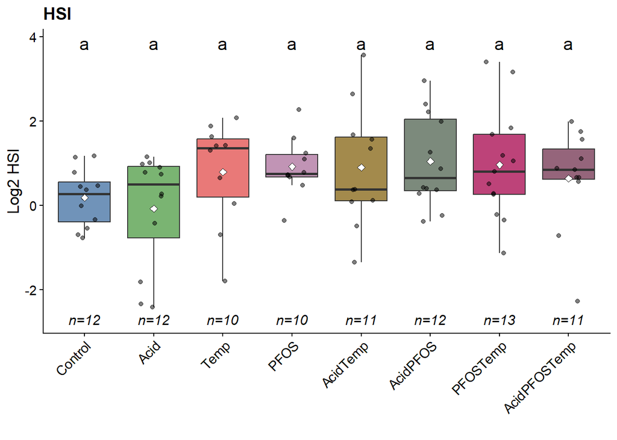

```r
#Compact letter display
cld_df <- as.data.frame(cld(emm, Letters = letters, adjust = "BH"))
cld_df$.group <- trimws(cld_df$.group)

#Sample sizes
n_df <- Data %>%
  filter(!is.na(log2_HSI)) %>%
  group_by(Condition) %>%
  summarise(n = n(), .groups = "drop") %>%
  mutate(label = paste0("n=", n))

#Plot
plot_HSI_females <- ggplot(Data, aes(x = Condition, y = log2_HSI, fill = Condition)) +
  geom_boxplot(alpha = 0.8, outlier.shape = NA) +
  geom_jitter(width = 0.2, size = 1.5, alpha = 0.5) +
  stat_summary(fun = mean, geom = "point", shape = 23, size = 2, fill = "white") +
  scale_fill_manual(values = myColors) +
  geom_text(data = cld_df, aes(x = Condition, y = 3.85, label = .group),
            size = 5, color = "black", inherit.aes = FALSE) +
  geom_text(data = n_df, aes(x = Condition, y = -2.7, label = label),
            size = 4, fontface = "italic", inherit.aes = FALSE) +
  labs(y = "Log2 HSI", x = "", title = "HSI") +
  theme_classic() +
  theme(legend.position = "none",
        axis.text.x = element_text(angle = 45, hjust = 1, size = 11),
        axis.text.y = element_text(size = 11),
        axis.title.y = element_text(size = 13),
        plot.title = element_text(size = 14, face = "bold"))
plot_HSI_females
```

```r
ggsave("HSI_plot.png", plot = plot_HSI_females,
       width = 7, height = 5, units = "in", dpi = 600)
```

## K analysis (condition factor)

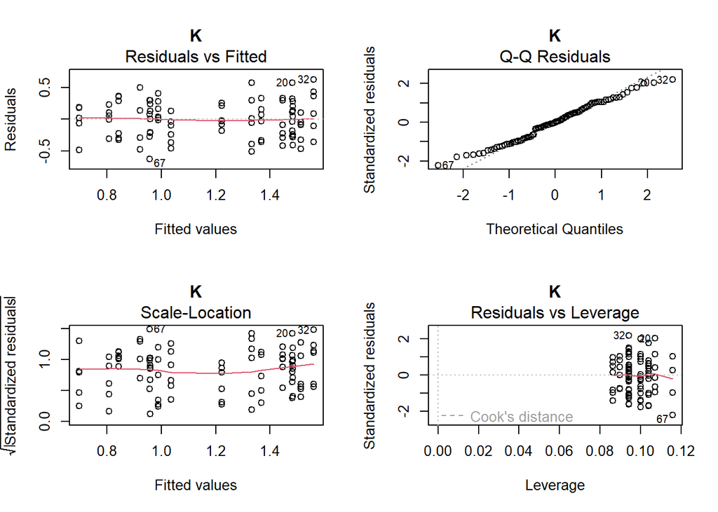

```r
#Diagnostic on standard lm
model_K <- lm(log2_K ~ Condition + Exposure, data = Data)
par(mfrow = c(2, 2))
plot(model_K, main = "K")
```

```r
#residuals vs fitted = random scatter around zero --> good
#QQ plot some outliers --> rlm

cooksd <- cooks.distance(model_K)
threshold <- 4 / (nrow(Data) - length(coef(model_K)))
outliers <- which(cooksd > threshold)
outliers
```

```
## 20 29 32 67
## 20 29 32 67
```

```r
Data[outliers, ]
```

```
## # A tibble: 4 × 28
##   Fish_nb Condition Exposure Sex     Condition_Sex  Length_thins Length Weight_g
##   <fct>   <fct>     <fct>    <chr>   <chr>                 <dbl>  <dbl>    <dbl>
## 1 44      PFOS      2        _Female PFOS_Female             3.4    2.2    0.444
## 2 59      AcidTemp  2        _Female AcidTemp_Fema…          2.2    1.7    0.184
## 3 66      AcidPFOS  2        _Female AcidPFOS_Fema…          2.9    2.3    0.554
## 4 42      PFOS      3        _Female PFOS_Female             2.9    2.4    0.173
## # ℹ 20 more variables: Weight_mg <dbl>, Weight_Gonad_g <dbl>,
## #   Weight_Liver_g <dbl>, Weight_Brain_g <dbl>, Weight_Gut_g <dbl>, Name <chr>,
## #   BSI <dbl>, HSI <dbl>, GSI <dbl>, K <dbl>, Sampling_Date <dbl>,
## #   Fish_age_months <dbl>, log2_Length_thins <dbl>, log2_Length <dbl>,
## #   log2_Weight <dbl>, log2_Weight_mg <dbl>, log2_BSI <dbl>, log2_HSI <dbl>,
## #   log2_GSI <dbl>, log2_K <dbl>
```

```r
#Robust regression
model_K_robust <- rlm(log2_K ~ Condition + Exposure, data = Data)

#Omnibus F-test
f.robftest(model_K_robust, var = c("ConditionAcid", "ConditionTemp", "ConditionPFOS",
                                   "ConditionAcidTemp", "ConditionAcidPFOS",
                                   "ConditionPFOSTemp", "ConditionAcidPFOSTemp"))
```

```
##
##  robust F-test (as if non-random weights)
##
## data:  from rlm(formula = log2_K ~ Condition + Exposure, data = Data)
## F = 1.3277, p-value = 0.2477
## alternative hypothesis: two.sided
## null values:
##         ConditionAcid         ConditionTemp         ConditionPFOS
##                     0                     0                     0
##     ConditionAcidTemp     ConditionAcidPFOS     ConditionPFOSTemp
##                     0                     0                     0
## ConditionAcidPFOSTemp
##                     0
```

```r
f.robftest(model_K_robust, var = "Exposure3")
```

```
##
##  robust F-test (as if non-random weights)
##
## data:  from rlm(formula = log2_K ~ Condition + Exposure, data = Data)
## F = 59.234, p-value = 2.609e-11
## alternative hypothesis: true Exposure3 is not equal to 0
```

```r
#Huge exposure effect --> makes sense as expo 2 fish are older --> bigger

#Sensitivity check: ANOVA without outliers (exploratory)
Data_no_out <- Data[!(rownames(Data) %in% outliers), ]
model_K_aov <- aov(log2_K ~ Condition + Exposure, data = Data_no_out)
summary(model_K_aov)
```

```
##             Df Sum Sq Mean Sq F value   Pr(>F)
## Condition    7  0.976   0.139   1.857   0.0879 .
## Exposure     1  4.779   4.779  63.630 9.67e-12 ***
## Residuals   79  5.933   0.075
## ---
## Signif. codes:  0 '***' 0.001 '**' 0.01 '*' 0.05 '.' 0.1 ' ' 1
```

```r
#Dunnett: each treatment vs Control
emm <- emmeans(model_K_robust, ~ Condition)
contrast(emm, method = "trt.vs.ctrl", ref = "Control")
```

```
##  contrast               estimate    SE df z.ratio p.value
##  Acid - Control          -0.1455 0.130 NA  -1.120  0.7388
##  Temp - Control          -0.0726 0.133 NA  -0.546  0.9664
##  PFOS - Control          -0.0237 0.136 NA  -0.174  0.9991
##  AcidTemp - Control      -0.1885 0.133 NA  -1.418  0.5502
##  AcidPFOS - Control       0.0318 0.130 NA   0.244  0.9974
##  PFOSTemp - Control      -0.0290 0.127 NA  -0.227  0.9979
##  AcidPFOSTemp - Control  -0.2868 0.133 NA  -2.158  0.1580
##
## Results are averaged over the levels of: Exposure
## P value adjustment: dunnettx method for 7 tests
```

```r
#All pairwise comparisons (BH-adjusted)
pairs(emm, adjust = "BH")
```

```
##  contrast                estimate    SE df z.ratio p.value
##  Control - Acid           0.14549 0.130 NA   1.120  0.6690
##  Control - Temp           0.07256 0.133 NA   0.546  0.8622
##  Control - PFOS           0.02372 0.136 NA   0.174  0.8939
##  Control - AcidTemp       0.18846 0.133 NA   1.418  0.6039
##  Control - AcidPFOS      -0.03175 0.130 NA  -0.244  0.8833
##  Control - PFOSTemp       0.02897 0.127 NA   0.227  0.8833
##  Control - AcidPFOSTemp   0.28684 0.133 NA   2.158  0.4100
##  Acid - Temp             -0.07293 0.133 NA  -0.549  0.8622
##  Acid - PFOS             -0.12177 0.136 NA  -0.892  0.7338
##  Acid - AcidTemp          0.04297 0.133 NA   0.323  0.8709
##  Acid - AcidPFOS         -0.17725 0.130 NA  -1.364  0.6039
##  Acid - PFOSTemp         -0.11652 0.127 NA  -0.914  0.7338
##  Acid - AcidPFOSTemp      0.14134 0.133 NA   1.064  0.6709
##  Temp - PFOS             -0.04884 0.139 NA  -0.351  0.8709
##  Temp - AcidTemp          0.11590 0.136 NA   0.854  0.7338
##  Temp - AcidPFOS         -0.10431 0.133 NA  -0.785  0.7568
##  Temp - PFOSTemp         -0.04359 0.130 NA  -0.334  0.8709
##  Temp - AcidPFOSTemp      0.21428 0.136 NA   1.579  0.5337
##  PFOS - AcidTemp          0.16474 0.139 NA   1.184  0.6617
##  PFOS - AcidPFOS         -0.05548 0.136 NA  -0.407  0.8709
##  PFOS - PFOSTemp          0.00525 0.134 NA   0.039  0.9687
##  PFOS - AcidPFOSTemp      0.26311 0.139 NA   1.891  0.4100
##  AcidTemp - AcidPFOS     -0.22022 0.133 NA  -1.657  0.5337
##  AcidTemp - PFOSTemp     -0.15949 0.130 NA  -1.223  0.6617
##  AcidTemp - AcidPFOSTemp  0.09838 0.136 NA   0.725  0.7717
##  AcidPFOS - PFOSTemp      0.06073 0.127 NA   0.477  0.8709
##  AcidPFOS - AcidPFOSTemp  0.31859 0.133 NA   2.397  0.4100
##  PFOSTemp - AcidPFOSTemp  0.25787 0.130 NA   1.978  0.4100
##
## Results are averaged over the levels of: Exposure
## P value adjustment: BH method for 28 tests
```

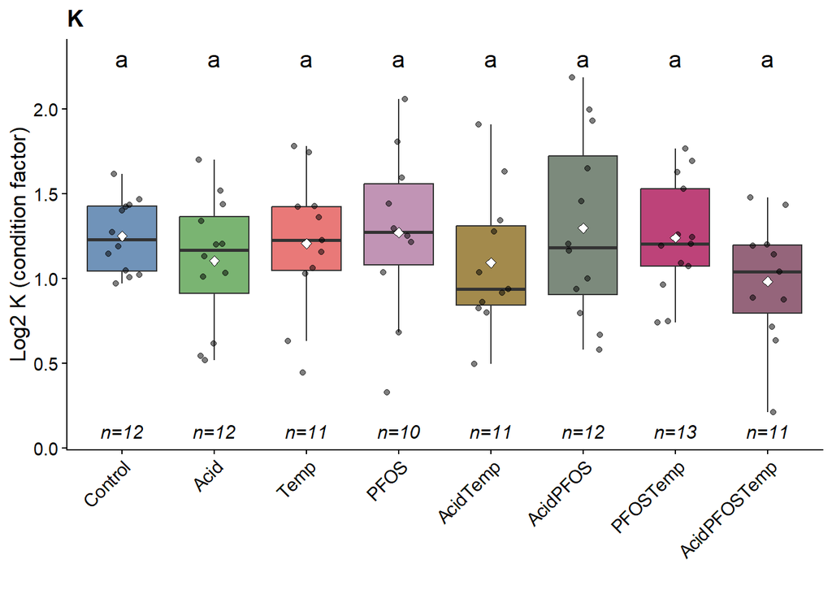

```r
#Compact letter display
cld_df <- as.data.frame(cld(emm, Letters = letters, adjust = "BH"))
cld_df$.group <- trimws(cld_df$.group)

#Sample sizes
n_df <- Data %>%
  filter(!is.na(log2_K)) %>%
  group_by(Condition) %>%
  summarise(n = n(), .groups = "drop") %>%
  mutate(label = paste0("n=", n))

#Plot
K_plot_females <- ggplot(Data, aes(x = Condition, y = log2_K, fill = Condition)) +
  geom_boxplot(alpha = 0.8, outlier.shape = NA) +
  geom_jitter(width = 0.2, size = 1.5, alpha = 0.5) +
  stat_summary(fun = mean, geom = "point", shape = 23, size = 2, fill = "white") +
  scale_fill_manual(values = myColors) +
  geom_text(data = cld_df, aes(x = Condition, y = 2.3, label = .group),
            size = 5, color = "black", inherit.aes = FALSE) +
  geom_text(data = n_df, aes(x = Condition, y = 0.1, label = label),
            size = 4, fontface = "italic", inherit.aes = FALSE) +
  labs(y = "Log2 K (condition factor)", x = "", title = "K") +
  theme_classic() +
  theme(legend.position = "none",
        axis.text.x = element_text(angle = 45, hjust = 1, size = 11),
        axis.text.y = element_text(size = 11),
        axis.title.y = element_text(size = 13),
        plot.title = element_text(size = 14, face = "bold"))
K_plot_females
```

```r
ggsave("K_plot.png", plot = K_plot_females,
       width = 7, height = 5, units = "in", dpi = 600)
```

## Mixture effects - factorial ANOVA

The 8 conditions are a 2×2×2 factorial (Acid × Temp × PFOS presence/absence). Decomposing Condition into 3 binary factors tests for additive vs interactive mixture effects.

```r
#Build 3 binary stressor factors from Condition
Data <- Data %>%
  mutate(
    Acid_f = factor(grepl("Acid", Condition), levels = c(FALSE, TRUE), labels = c("No", "Yes")),
    Temp_f = factor(grepl("Temp", Condition), levels = c(FALSE, TRUE), labels = c("No", "Yes")),
    PFOS_f = factor(grepl("PFOS", Condition), levels = c(FALSE, TRUE), labels = c("No", "Yes"))
  )

#Sanity check: each Condition maps to the right combination
table(Data$Condition, Data$Acid_f)
```

```
##
##                No Yes
##   Control      12   0
##   Acid          0  12
##   Temp         11   0
##   PFOS         10   0
##   AcidTemp      0  11
##   AcidPFOS      0  12
##   PFOSTemp     13   0
##   AcidPFOSTemp  0  11
```

```r
table(Data$Condition, Data$Temp_f)
```

```
##
##                No Yes
##   Control      12   0
##   Acid         12   0
##   Temp          0  11
##   PFOS         10   0
##   AcidTemp      0  11
##   AcidPFOS     12   0
##   PFOSTemp      0  13
##   AcidPFOSTemp  0  11
```

```r
table(Data$Condition, Data$PFOS_f)
```

```
##
##                No Yes
##   Control      12   0
##   Acid         12   0
##   Temp         11   0
##   PFOS          0  10
##   AcidTemp     11   0
##   AcidPFOS      0  12
##   PFOSTemp      0  13
##   AcidPFOSTemp  0  11
```

```r
#Factorial ANOVA for each endpoint
#Significant main effects --> that stressor has an effect on average across all combinations
#Significant 2-way interaction --> non-additive mixture effect (synergy or antagonism) = the effects of X differs depending on Y present or not
#Significant 3-way interaction --> triple-mixture behaves differently than 2-way predicts

cat("\n===== LENGTH =====\n")
```

```
##
## ===== LENGTH =====
```

```r
Anova(lm(log2_Length ~ Acid_f * Temp_f * PFOS_f + Exposure, data = Data), type ="II")
```

```
## Anova Table (Type II tests)
##
## Response: log2_Length
##                       Sum Sq Df F value    Pr(>F)
## Acid_f               0.00998  1  0.7275 0.3961645
## Temp_f               0.12666  1  9.2338 0.0031766 **
## PFOS_f               0.16009  1 11.6709 0.0009852 ***
## Exposure             0.00295  1  0.2148 0.6442471
## Acid_f:Temp_f        0.04001  1  2.9167 0.0914032 .
## Acid_f:PFOS_f        0.07415  1  5.4057 0.0225132 *
## Temp_f:PFOS_f        0.00238  1  0.1737 0.6779527
## Acid_f:Temp_f:PFOS_f 0.04707  1  3.4318 0.0675057 .
## Residuals            1.13850 83
## ---
## Signif. codes:  0 '***' 0.001 '**' 0.01 '*' 0.05 '.' 0.1 ' ' 1
```

```r
cat("\n===== WEIGHT =====\n")
```

```
##
## ===== WEIGHT =====
```

```r
Anova(lm(log2_Weight_mg ~ Acid_f * Temp_f * PFOS_f + Exposure, data = Data), type ="II")
```

```
## Anova Table (Type II tests)
##
## Response: log2_Weight_mg
##                      Sum Sq Df F value    Pr(>F)
## Acid_f               0.7188  1  9.1557 0.0033007 **
## Temp_f               2.5364  1 32.3084 1.904e-07 ***
## PFOS_f               1.7587  1 22.4025 8.986e-06 ***
## Exposure             5.5036  1 70.1048 1.174e-12 ***
## Acid_f:Temp_f        0.9341  1 11.8990 0.0008851 ***
## Acid_f:PFOS_f        0.8250  1 10.5089 0.0017112 **
## Temp_f:PFOS_f        0.0185  1  0.2352 0.6289913
## Acid_f:Temp_f:PFOS_f 1.2010  1 15.2980 0.0001870 ***
## Residuals            6.5159 83
## ---
## Signif. codes:  0 '***' 0.001 '**' 0.01 '*' 0.05 '.' 0.1 ' ' 1
```

```r
cat("\n===== HSI =====\n")
```

```
##
## ===== HSI =====
```

```r
Anova(lm(log2_HSI ~ Acid_f * Temp_f * PFOS_f + Exposure, data = Data), type ="II")
```

```
## Anova Table (Type II tests)
##
## Response: log2_HSI
##                       Sum Sq Df F value  Pr(>F)
## Acid_f                 0.216  1  0.1581 0.69196
## Temp_f                 2.059  1  1.5058 0.22329
## PFOS_f                 4.608  1  3.3703 0.07001 .
## Exposure               0.109  1  0.0796 0.77851
## Acid_f:Temp_f          0.013  1  0.0093 0.92337
## Acid_f:PFOS_f          0.001  1  0.0008 0.97710
## Temp_f:PFOS_f          5.436  1  3.9761 0.04947 *
## Acid_f:Temp_f:PFOS_f   0.951  1  0.6957 0.40665
## Residuals            112.116 82
## ---
## Signif. codes:  0 '***' 0.001 '**' 0.01 '*' 0.05 '.' 0.1 ' ' 1
```

```r
cat("\n===== K =====\n")
```

```
##
## ===== K =====
```

```r
Anova(lm(log2_K ~ Acid_f * Temp_f * PFOS_f + Exposure, data = Data), type ="II")
```

```
## Anova Table (Type II tests)
##
## Response: log2_K
##                      Sum Sq Df F value   Pr(>F)
## Acid_f               0.3004  1  3.3121  0.07237 .
## Temp_f               0.2755  1  3.0377  0.08505 .
## PFOS_f               0.0158  1  0.1746  0.67718
## Exposure             6.2942  1 69.3881 1.43e-12 ***
## Acid_f:Temp_f        0.1343  1  1.4803  0.22717
## Acid_f:PFOS_f        0.0084  1  0.0921  0.76233
## Temp_f:PFOS_f        0.0797  1  0.8785  0.35132
## Acid_f:Temp_f:PFOS_f 0.1980  1  2.1830  0.14333
## Residuals            7.5289 83
## ---
## Signif. codes:  0 '***' 0.001 '**' 0.01 '*' 0.05 '.' 0.1 ' ' 1
```

## Create the final figure

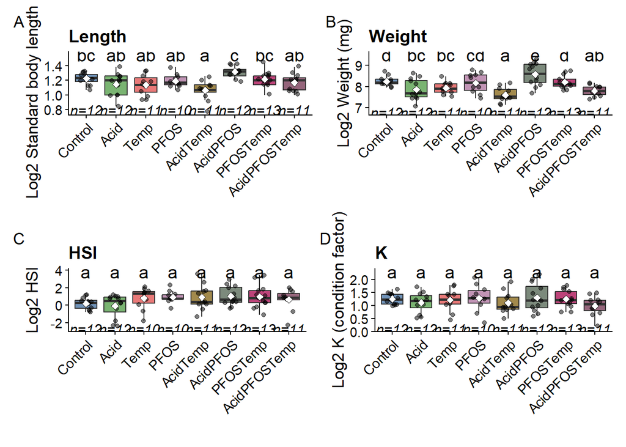

```r
combined_plot <- (length_plot_females + weight_plot_females) /
                 (plot_HSI_females + K_plot_females) +
  plot_annotation(tag_levels = "A")

combined_plot
```

```r
ggsave("Fig_morphology_females.png", plot = combined_plot,
       width = 14, height = 10, units = "in", dpi = 600)
```

## Summary

Robust reductions in length and weight are observed under some conditions, while K remains unchanged, suggesting stress-induced reduction in somatic growth without disproportionate changes in body composition. Factorial ANOVA reveals significant Acid × PFOS interactions for length and weight, as well as Acid × Temp and Acid × PFOS × Temp interactions for weight, indicating non-additive mixture effects.